# creditcard_fraud

## Credit Card Fraud Detection using Scikit-Learn

### Objectives

- Perform basic data preprocessing in Python
- Model a classification task using the Scikit-Learn
- Train Support Vector Machine and Decision Tree using Scikit-Learn
- Run inference and access the quality of the trained models

```python
#Import libraries
from __future__ import print_function
import numpy as np
import pandas as pd
import matplotlib.pyplot as plt
%matplotlib inline
from sklearn.model_selection import train_test_split
from sklearn.preprocessing import normalize, StandardScaler
from sklearn.utils.class_weight import compute_sample_weight
from sklearn.metrics import roc_auc_score
import time
import warnings
warnings.filterwarnings('ignore')
```

```python
raw_data = pd.read_csv('creditcard.csv')
raw_data.head()
```

|  | Time | V1 | V2 | V3 | V4 | V5 | V6 | V7 | V8 | V9 | ... | V21 | V22 | V23 | V24 | V25 | V26 | V27 | V28 | Amount | Class |
| --- | --- | --- | --- | --- | --- | --- | --- | --- | --- | --- | --- | --- | --- | --- | --- | --- | --- | --- | --- | --- | --- |
| 0 | 0.0 | -1.359807 | -0.072781 | 2.536347 | 1.378155 | -0.338321 | 0.462388 | 0.239599 | 0.098698 | 0.363787 | ... | -0.018307 | 0.277838 | -0.110474 | 0.066928 | 0.128539 | -0.189115 | 0.133558 | -0.021053 | 149.62 | 0 |
| 1 | 0.0 | 1.191857 | 0.266151 | 0.166480 | 0.448154 | 0.060018 | -0.082361 | -0.078803 | 0.085102 | -0.255425 | ... | -0.225775 | -0.638672 | 0.101288 | -0.339846 | 0.167170 | 0.125895 | -0.008983 | 0.014724 | 2.69 | 0 |
| 2 | 1.0 | -1.358354 | -1.340163 | 1.773209 | 0.379780 | -0.503198 | 1.800499 | 0.791461 | 0.247676 | -1.514654 | ... | 0.247998 | 0.771679 | 0.909412 | -0.689281 | -0.327642 | -0.139097 | -0.055353 | -0.059752 | 378.66 | 0 |
| 3 | 1.0 | -0.966272 | -0.185226 | 1.792993 | -0.863291 | -0.010309 | 1.247203 | 0.237609 | 0.377436 | -1.387024 | ... | -0.108300 | 0.005274 | -0.190321 | -1.175575 | 0.647376 | -0.221929 | 0.062723 | 0.061458 | 123.50 | 0 |
| 4 | 2.0 | -1.158233 | 0.877737 | 1.548718 | 0.403034 | -0.407193 | 0.095921 | 0.592941 | -0.270533 | 0.817739 | ... | -0.009431 | 0.798278 | -0.137458 | 0.141267 | -0.206010 | 0.502292 | 0.219422 | 0.215153 | 69.99 | 0 |

5 rows × 31 columns

## Dataset Analysis

```python
print("There are " + str(len(raw_data)) + " observations in the credit card fraud dataset.")
print("There are " + str(len(raw_data.columns)) + " variables in the dataset.")
```

```
There are 284807 observations in the credit card fraud dataset.
There are 31 variables in the dataset.
```

In practice, a financial institution may have access to a much larger dataset of transactions. To simulate such a case, we will inflate the original one 10 times.

```python
n_replicas = 10

# Inflate the original dataset
big_raw_data = pd.DataFrame(np.repeat(raw_data.values, n_replicas, axis = 0), columns = raw_data.columns)

print("There are " + str(len(big_raw_data)) + " observations in the credit card fraud dataset.")
print("There are " + str(len(big_raw_data.columns)) + " variables in the dataset.")

#Display the data
big_raw_data.head()
```

```
There are 2848070 observations in the credit card fraud dataset.
There are 31 variables in the dataset.
```

|  | Time | V1 | V2 | V3 | V4 | V5 | V6 | V7 | V8 | V9 | ... | V21 | V22 | V23 | V24 | V25 | V26 | V27 | V28 | Amount | Class |
| --- | --- | --- | --- | --- | --- | --- | --- | --- | --- | --- | --- | --- | --- | --- | --- | --- | --- | --- | --- | --- | --- |
| 0 | 0.0 | -1.359807 | -0.072781 | 2.536347 | 1.378155 | -0.338321 | 0.462388 | 0.239599 | 0.098698 | 0.363787 | ... | -0.018307 | 0.277838 | -0.110474 | 0.066928 | 0.128539 | -0.189115 | 0.133558 | -0.021053 | 149.62 | 0.0 |
| 1 | 0.0 | -1.359807 | -0.072781 | 2.536347 | 1.378155 | -0.338321 | 0.462388 | 0.239599 | 0.098698 | 0.363787 | ... | -0.018307 | 0.277838 | -0.110474 | 0.066928 | 0.128539 | -0.189115 | 0.133558 | -0.021053 | 149.62 | 0.0 |
| 2 | 0.0 | -1.359807 | -0.072781 | 2.536347 | 1.378155 | -0.338321 | 0.462388 | 0.239599 | 0.098698 | 0.363787 | ... | -0.018307 | 0.277838 | -0.110474 | 0.066928 | 0.128539 | -0.189115 | 0.133558 | -0.021053 | 149.62 | 0.0 |
| 3 | 0.0 | -1.359807 | -0.072781 | 2.536347 | 1.378155 | -0.338321 | 0.462388 | 0.239599 | 0.098698 | 0.363787 | ... | -0.018307 | 0.277838 | -0.110474 | 0.066928 | 0.128539 | -0.189115 | 0.133558 | -0.021053 | 149.62 | 0.0 |
| 4 | 0.0 | -1.359807 | -0.072781 | 2.536347 | 1.378155 | -0.338321 | 0.462388 | 0.239599 | 0.098698 | 0.363787 | ... | -0.018307 | 0.277838 | -0.110474 | 0.066928 | 0.128539 | -0.189115 | 0.133558 | -0.021053 | 149.62 | 0.0 |

5 rows × 31 columns

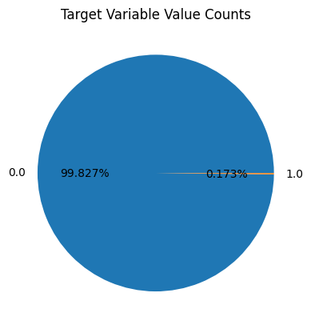

```python
#Get the set of distinct classes
labels = big_raw_data.Class.unique()

#get the count of each class
sizes = big_raw_data.Class.value_counts().values

#Plot the class value counts
fig, ax = plt.subplots()
ax.pie(sizes, labels = labels, autopct = '%1.3f%%')
ax.set_title('Target Variable Value Counts')
plt.show()
```

The Class variable has two values:

- 0: The credit card transaction is legitimate
- 1: The credit card transaction is fraudulent

Besides, the data set is highly unbalanced which 99.827% of transactions is legitimate and 0.173% of transactions is fraudulent. Therefore, this case would require special attention when training or when evaluating the quality of a model.

One way of handling is to bias the model to pay more attention to the samples in the minority class. The models under the current study will be configured to take into account the class weights of the samples at train/fit time.

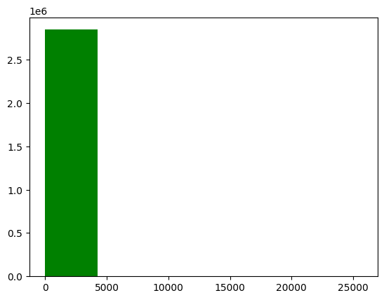

```
Minimum amount value is  0.0
Maximum amount value is  25691.16
90% of the transactions have an amount less or equal than  203.0
```

```python
#PLot a histogram that shows the distribution of the different amounts of the credit card transactions
plt.hist(big_raw_data.Amount.values, 6, histtype='bar', facecolor = 'g')
plt.show()

print("Minimum amount value is ", np.min(big_raw_data.Amount.values))
print("Maximum amount value is ", np.max(big_raw_data.Amount.values))
print("90% of the transactions have an amount less or equal than ", np.percentile(raw_data.Amount.values, 90))
```

## Data Preprocessing

```python
#Standardize features by removing the mean and scaling to unit variance
big_raw_data.iloc[:, 1:30] = StandardScaler().fit_transform(big_raw_data.iloc[:, 1:30])
data_matrix = big_raw_data.values

# X: feature matrix (for this analysis, we exclude the Time variable from the dataset)
X = data_matrix[:, 1:30]

# y: labels vector
y = data_matrix[:, 30]

# data normalization
X = normalize(X, norm="l1")

# print the shape of the features matrix and the labels vector
print('X.shape=', X.shape, 'y.shape=', y.shape)
```

```
X.shape= (2848070, 29) y.shape= (2848070,)
```

## Dataset Train/Test Split

```python
X_train, X_test, y_train, y_test = train_test_split(X,y, test_size= 0.3, random_state= 42, stratify= y)
print("X_train.shape = ", X_train.shape, "Y_train.shape = ", y_train.shape)
print("X_test.shape = ", X_test.shape, "Y_test.shape = ", y_test.shape)
```

```
X_train.shape =  (1993649, 29) Y_train.shape =  (1993649,)
X_test.shape =  (854421, 29) Y_test.shape =  (854421,)
```

## Build a Decision Tree Classifier model

```python
#Compute the sample weights to be used as input to the train routine so that
#it take into account the class imbalance present in this dataset
w_train = compute_sample_weight('balanced', y_train)

#import the Decision Tree Classifier Model from scikit-learn
from sklearn.tree import DecisionTreeClassifier

#for reproducible output across multiple function calls, set random_state to a given integer value
sklearn_dt = DecisionTreeClassifier(max_depth= 4, random_state= 35)
sklearn_dt.fit(X_train, y_train, sample_weight= w_train)
```

```
DecisionTreeClassifier(max_depth=4, random_state=35)
```

## Evaluate the Decision Tree Classifier models

```python
# run inference and compute the probabilities of the test samples
# to belong to the class of fraudulent transactions
sklearn_pred = sklearn_dt.predict_proba(X_test)[:,1]

# evaluate the Compute Area Under the Receiver Operating Characteristic
# Curve (ROC-AUC) score from the predictions
sklearn_roc_auc = roc_auc_score(y_test, sklearn_pred)
print("ROC-AUC score: {0:.3f}".format(sklearn_roc_auc))
```

```
ROC-AUC score: 0.966
```

## Build a Support Vector Machine model

```python
from sklearn.svm import LinearSVC

#Instatiate a scikit-learn SVM model
#To indicate the class imbalance at fit time, set class_weight = 'balanced'
#For reproducible output across multiple function calls, set random_state to a given integer value
sklearn_svm = LinearSVC(class_weight= 'balanced', random_state= 31, loss = 'hinge', fit_intercept = False)

#train a linear Support Vector Machine model using Scikit-learn
sklearn_svm.fit(X_train, y_train)
```

```
LinearSVC(class_weight='balanced', fit_intercept=False, loss='hinge',
          random_state=31)
```

## Evaluate the Support Vector Machine models

```python
#Run inference using the Scikit-learn model
#get the confidence scores for the test samples
sklearn_pred = sklearn_svm.decision_function(X_test)

#Evaluate accuracy on test set
acc_sklearn = roc_auc_score(y_test, sklearn_pred)
print("ROC-AUC score: {0:.3f}".format(acc_sklearn))
```

```
ROC-AUC score: 0.984
```

#### Evaluate the quality of the SVM models using hinge-loss metric

```python
#Get the confidence scores for the test samples
sklearn_pred = sklearn_svm.decision_function(X_test)

#import library
from sklearn.metrics import hinge_loss

#Evaluate the hinge-loss from the predictions
loss_sklearn = hinge_loss(y_test, sklearn_pred)
print("Hinge loss: {0:.3f}".format(loss_sklearn))
```

```
Hinge loss: 0.234
```